# Communicate Data Findings with Loan Data from Prosper

## Data Wrangling

**Firstly, we will import some necessary libraries, the dataset, and do some data wrangling to have a dataset of better quality.**

```python
# import all packages and set plots to be embedded inline
import numpy as np
import pandas as pd
import matplotlib.pyplot as plt
import seaborn as sb
from wordcloud import WordCloud

%matplotlib inline
```

> Load in the dataset and take a quick look at its properties.

```python
# load the raw dataset
df_loan_data = pd.read_csv('prosperLoanData.csv')
df_loan_data.head(10)
```

|  | ListingKey | ListingNumber | ListingCreationDate | CreditGrade | Term | LoanStatus | ClosedDate | BorrowerAPR | BorrowerRate | LenderYield | ... | LP_ServiceFees | LP_CollectionFees | LP_GrossPrincipalLoss | LP_NetPrincipalLoss | LP_NonPrincipalRecoverypayments | PercentFunded | Recommendations | InvestmentFromFriendsCount | InvestmentFromFriendsAmount | Investors |
| --- | --- | --- | --- | --- | --- | --- | --- | --- | --- | --- | --- | --- | --- | --- | --- | --- | --- | --- | --- | --- | --- |
| 0 | 1021339766868145413AB3B | 193129 | 2007-08-26 19:09:29.263000000 | C | 36 | Completed | 2009-08-14 00:00:00 | 0.16516 | 0.1580 | 0.1380 | ... | -133.18 | 0.0 | 0.0 | 0.0 | 0.0 | 1.0 | 0 | 0 | 0.0 | 258 |
| 1 | 10273602499503308B223C1 | 1209647 | 2014-02-27 08:28:07.900000000 | NaN | 36 | Current | NaN | 0.12016 | 0.0920 | 0.0820 | ... | 0.00 | 0.0 | 0.0 | 0.0 | 0.0 | 1.0 | 0 | 0 | 0.0 | 1 |
| 2 | 0EE9337825851032864889A | 81716 | 2007-01-05 15:00:47.090000000 | HR | 36 | Completed | 2009-12-17 00:00:00 | 0.28269 | 0.2750 | 0.2400 | ... | -24.20 | 0.0 | 0.0 | 0.0 | 0.0 | 1.0 | 0 | 0 | 0.0 | 41 |
| 3 | 0EF5356002482715299901A | 658116 | 2012-10-22 11:02:35.010000000 | NaN | 36 | Current | NaN | 0.12528 | 0.0974 | 0.0874 | ... | -108.01 | 0.0 | 0.0 | 0.0 | 0.0 | 1.0 | 0 | 0 | 0.0 | 158 |
| 4 | 0F023589499656230C5E3E2 | 909464 | 2013-09-14 18:38:39.097000000 | NaN | 36 | Current | NaN | 0.24614 | 0.2085 | 0.1985 | ... | -60.27 | 0.0 | 0.0 | 0.0 | 0.0 | 1.0 | 0 | 0 | 0.0 | 20 |
| 5 | 0F05359734824199381F61D | 1074836 | 2013-12-14 08:26:37.093000000 | NaN | 60 | Current | NaN | 0.15425 | 0.1314 | 0.1214 | ... | -25.33 | 0.0 | 0.0 | 0.0 | 0.0 | 1.0 | 0 | 0 | 0.0 | 1 |
| 6 | 0F0A3576754255009D63151 | 750899 | 2013-04-12 09:52:56.147000000 | NaN | 36 | Current | NaN | 0.31032 | 0.2712 | 0.2612 | ... | -22.95 | 0.0 | 0.0 | 0.0 | 0.0 | 1.0 | 0 | 0 | 0.0 | 1 |
| 7 | 0F1035772717087366F9EA7 | 768193 | 2013-05-05 06:49:27.493000000 | NaN | 36 | Current | NaN | 0.23939 | 0.2019 | 0.1919 | ... | -69.21 | 0.0 | 0.0 | 0.0 | 0.0 | 1.0 | 0 | 0 | 0.0 | 1 |
| 8 | 0F043596202561788EA13D5 | 1023355 | 2013-12-02 10:43:39.117000000 | NaN | 36 | Current | NaN | 0.07620 | 0.0629 | 0.0529 | ... | -16.77 | 0.0 | 0.0 | 0.0 | 0.0 | 1.0 | 0 | 0 | 0.0 | 1 |
| 9 | 0F043596202561788EA13D5 | 1023355 | 2013-12-02 10:43:39.117000000 | NaN | 36 | Current | NaN | 0.07620 | 0.0629 | 0.0529 | ... | -16.77 | 0.0 | 0.0 | 0.0 | 0.0 | 1.0 | 0 | 0 | 0.0 | 1 |

10 rows × 81 columns

```python
# the shape of the original dataset
df_loan_data.shape
```

```
(113937, 81)
```

```python
# general information about the loan dataset
df_loan_data.info()
```

```
<class 'pandas.core.frame.DataFrame'>
RangeIndex: 113937 entries, 0 to 113936
Data columns (total 81 columns):
ListingKey                             113937 non-null object
ListingNumber                          113937 non-null int64
ListingCreationDate                    113937 non-null object
CreditGrade                            28953 non-null object
Term                                   113937 non-null int64
LoanStatus                             113937 non-null object
ClosedDate                             55089 non-null object
BorrowerAPR                            113912 non-null float64
BorrowerRate                           113937 non-null float64
LenderYield                            113937 non-null float64
EstimatedEffectiveYield                84853 non-null float64
EstimatedLoss                          84853 non-null float64
EstimatedReturn                        84853 non-null float64
ProsperRating (numeric)                84853 non-null float64
ProsperRating (Alpha)                  84853 non-null object
ProsperScore                           84853 non-null float64
ListingCategory (numeric)              113937 non-null int64
BorrowerState                          108422 non-null object
Occupation                             110349 non-null object
EmploymentStatus                       111682 non-null object
EmploymentStatusDuration               106312 non-null float64
IsBorrowerHomeowner                    113937 non-null bool
CurrentlyInGroup                       113937 non-null bool
GroupKey                               13341 non-null object
DateCreditPulled                       113937 non-null object
CreditScoreRangeLower                  113346 non-null float64
CreditScoreRangeUpper                  113346 non-null float64
FirstRecordedCreditLine                113240 non-null object
CurrentCreditLines                     106333 non-null float64
OpenCreditLines                        106333 non-null float64
TotalCreditLinespast7years             113240 non-null float64
OpenRevolvingAccounts                  113937 non-null int64
OpenRevolvingMonthlyPayment            113937 non-null float64
InquiriesLast6Months                   113240 non-null float64
TotalInquiries                         112778 non-null float64
CurrentDelinquencies                   113240 non-null float64
AmountDelinquent                       106315 non-null float64
```

[output cut: 31 more lines]

```
LP_CustomerPayments                    113937 non-null float64
LP_CustomerPrincipalPayments           113937 non-null float64
LP_InterestandFees                     113937 non-null float64
LP_ServiceFees                         113937 non-null float64
LP_CollectionFees                      113937 non-null float64
LP_GrossPrincipalLoss                  113937 non-null float64
LP_NetPrincipalLoss                    113937 non-null float64
LP_NonPrincipalRecoverypayments        113937 non-null float64
PercentFunded                          113937 non-null float64
Recommendations                        113937 non-null int64
InvestmentFromFriendsCount             113937 non-null int64
InvestmentFromFriendsAmount            113937 non-null float64
Investors                              113937 non-null int64
dtypes: bool(3), float64(50), int64(11), object(17)
memory usage: 68.1+ MB
```

```python
df_loan_data.describe()
```

|  | ListingNumber | Term | BorrowerAPR | BorrowerRate | LenderYield | EstimatedEffectiveYield | EstimatedLoss | EstimatedReturn | ProsperRating (numeric) | ProsperScore | ... | LP_ServiceFees | LP_CollectionFees | LP_GrossPrincipalLoss | LP_NetPrincipalLoss | LP_NonPrincipalRecoverypayments | PercentFunded | Recommendations | InvestmentFromFriendsCount | InvestmentFromFriendsAmount | Investors |
| --- | --- | --- | --- | --- | --- | --- | --- | --- | --- | --- | --- | --- | --- | --- | --- | --- | --- | --- | --- | --- | --- |
| count | 1.139370e+05 | 113937.000000 | 113912.000000 | 113937.000000 | 113937.000000 | 84853.000000 | 84853.000000 | 84853.000000 | 84853.000000 | 84853.000000 | ... | 113937.000000 | 113937.000000 | 113937.000000 | 113937.000000 | 113937.000000 | 113937.000000 | 113937.000000 | 113937.000000 | 113937.000000 | 113937.000000 |
| mean | 6.278857e+05 | 40.830248 | 0.218828 | 0.192764 | 0.182701 | 0.168661 | 0.080306 | 0.096068 | 4.072243 | 5.950067 | ... | -54.725641 | -14.242698 | 700.446342 | 681.420499 | 25.142686 | 0.998584 | 0.048027 | 0.023460 | 16.550751 | 80.475228 |
| std | 3.280762e+05 | 10.436212 | 0.080364 | 0.074818 | 0.074516 | 0.068467 | 0.046764 | 0.030403 | 1.673227 | 2.376501 | ... | 60.675425 | 109.232758 | 2388.513831 | 2357.167068 | 275.657937 | 0.017919 | 0.332353 | 0.232412 | 294.545422 | 103.239020 |
| min | 4.000000e+00 | 12.000000 | 0.006530 | 0.000000 | -0.010000 | -0.182700 | 0.004900 | -0.182700 | 1.000000 | 1.000000 | ... | -664.870000 | -9274.750000 | -94.200000 | -954.550000 | 0.000000 | 0.700000 | 0.000000 | 0.000000 | 0.000000 | 1.000000 |
| 25% | 4.009190e+05 | 36.000000 | 0.156290 | 0.134000 | 0.124200 | 0.115670 | 0.042400 | 0.074080 | 3.000000 | 4.000000 | ... | -73.180000 | 0.000000 | 0.000000 | 0.000000 | 0.000000 | 1.000000 | 0.000000 | 0.000000 | 0.000000 | 2.000000 |
| 50% | 6.005540e+05 | 36.000000 | 0.209760 | 0.184000 | 0.173000 | 0.161500 | 0.072400 | 0.091700 | 4.000000 | 6.000000 | ... | -34.440000 | 0.000000 | 0.000000 | 0.000000 | 0.000000 | 1.000000 | 0.000000 | 0.000000 | 0.000000 | 44.000000 |
| 75% | 8.926340e+05 | 36.000000 | 0.283810 | 0.250000 | 0.240000 | 0.224300 | 0.112000 | 0.116600 | 5.000000 | 8.000000 | ... | -13.920000 | 0.000000 | 0.000000 | 0.000000 | 0.000000 | 1.000000 | 0.000000 | 0.000000 | 0.000000 | 115.000000 |
| max | 1.255725e+06 | 60.000000 | 0.512290 | 0.497500 | 0.492500 | 0.319900 | 0.366000 | 0.283700 | 7.000000 | 11.000000 | ... | 32.060000 | 0.000000 | 25000.000000 | 25000.000000 | 21117.900000 | 1.012500 | 39.000000 | 33.000000 | 25000.000000 | 1189.000000 |

8 rows × 61 columns

```python
# the number of duplicates in the data
df_loan_data.duplicated().sum()
```

```
0
```

```python
# the number of null values in the data
df_loan_data.isnull().sum()
```

```
ListingKey                                  0
ListingNumber                               0
ListingCreationDate                         0
CreditGrade                             84984
Term                                        0
LoanStatus                                  0
ClosedDate                              58848
BorrowerAPR                                25
BorrowerRate                                0
LenderYield                                 0
EstimatedEffectiveYield                 29084
EstimatedLoss                           29084
EstimatedReturn                         29084
ProsperRating (numeric)                 29084
ProsperRating (Alpha)                   29084
ProsperScore                            29084
ListingCategory (numeric)                   0
BorrowerState                            5515
Occupation                               3588
EmploymentStatus                         2255
EmploymentStatusDuration                 7625
IsBorrowerHomeowner                         0
CurrentlyInGroup                            0
GroupKey                               100596
DateCreditPulled                            0
CreditScoreRangeLower                     591
CreditScoreRangeUpper                     591
FirstRecordedCreditLine                   697
CurrentCreditLines                       7604
OpenCreditLines                          7604
                                        ...
TotalProsperLoans                       91852
TotalProsperPaymentsBilled              91852
OnTimeProsperPayments                   91852
ProsperPaymentsLessThanOneMonthLate     91852
ProsperPaymentsOneMonthPlusLate         91852
ProsperPrincipalBorrowed                91852
ProsperPrincipalOutstanding             91852
ScorexChangeAtTimeOfListing             95009
LoanCurrentDaysDelinquent                   0
LoanFirstDefaultedCycleNumber           96985
LoanMonthsSinceOrigination                  0
LoanNumber                                  0
LoanOriginalAmount                          0
LoanOriginationDate                         0
LoanOriginationQuarter                      0
MemberKey                                   0
MonthlyLoanPayment                          0
LP_CustomerPayments                         0
LP_CustomerPrincipalPayments                0
LP_InterestandFees                          0
LP_ServiceFees                              0
LP_CollectionFees                           0
LP_GrossPrincipalLoss                       0
LP_NetPrincipalLoss                         0
LP_NonPrincipalRecoverypayments             0
PercentFunded                               0
Recommendations                             0
InvestmentFromFriendsCount                  0
InvestmentFromFriendsAmount                 0
Investors                                   0
Length: 81, dtype: int64
```

```python
# as the ProsperScore is a core variable in the investigation I want to do,
# the rows with missing ProsperScore should be dropped
# create a df_clean is a copy of the original data, with not null ProsperScore

df_clean = df_loan_data[df_loan_data['ProsperScore'].isnull()==False]
```

```python
# remove columns with too many null values and are not helpful for the investigation

df_clean.drop(['ListingNumber', 'CreditGrade', 'ClosedDate', 'BorrowerRate', 'LenderYield', 'EstimatedLoss', \
               'EmploymentStatusDuration', 'CurrentlyInGroup', 'GroupKey', 'DateCreditPulled', \
               'FirstRecordedCreditLine', 'TotalCreditLinespast7years',  'OpenRevolvingMonthlyPayment',\
               'AmountDelinquent', 'DelinquenciesLast7Years', 'PublicRecordsLast10Years', 'PublicRecordsLast12Months',\
               'RevolvingCreditBalance', 'TotalTrades', 'TradesNeverDelinquent (percentage)', 'TradesOpenedLast6Months',\
               'LoanKey', 'TotalProsperLoans', 'TotalProsperPaymentsBilled', 'OnTimeProsperPayments', \
               'ProsperPaymentsLessThanOneMonthLate', 'ProsperPaymentsOneMonthPlusLate', 'IncomeVerifiable',\
               'ProsperPrincipalBorrowed', 'ProsperPrincipalOutstanding', 'ScorexChangeAtTimeOfListing', \
               'LoanCurrentDaysDelinquent', 'LoanFirstDefaultedCycleNumber','MemberKey', 'MonthlyLoanPayment',\
              'LP_CustomerPayments', 'LP_CustomerPrincipalPayments', 'LP_InterestandFees', 'LP_ServiceFees',\
              'LP_CollectionFees', 'LP_GrossPrincipalLoss', 'LP_NetPrincipalLoss', 'LP_NonPrincipalRecoverypayments',\
              'PercentFunded', 'Recommendations', 'Recommendations', 'InvestmentFromFriendsCount',\
              'InvestmentFromFriendsAmount','Investors'], axis=1, inplace = True)
```

**Explanations for the drop** After looking at the Prosper Loan Data - Variable Definitions which provide a clear description about the data variables, as well as looking at several rows of the data, I selected the above variables to be insignificant features and dropped it from the data for an easier evaluation.

```python
df_clean.info()
```

```
<class 'pandas.core.frame.DataFrame'>
Int64Index: 84853 entries, 1 to 113936
Data columns (total 33 columns):
ListingKey                    84853 non-null object
ListingCreationDate           84853 non-null object
Term                          84853 non-null int64
LoanStatus                    84853 non-null object
BorrowerAPR                   84853 non-null float64
EstimatedEffectiveYield       84853 non-null float64
EstimatedReturn               84853 non-null float64
ProsperRating (numeric)       84853 non-null float64
ProsperRating (Alpha)         84853 non-null object
ProsperScore                  84853 non-null float64
ListingCategory (numeric)     84853 non-null int64
BorrowerState                 84853 non-null object
Occupation                    83520 non-null object
EmploymentStatus              84853 non-null object
IsBorrowerHomeowner           84853 non-null bool
CreditScoreRangeLower         84853 non-null float64
CreditScoreRangeUpper         84853 non-null float64
CurrentCreditLines            84853 non-null float64
OpenCreditLines               84853 non-null float64
OpenRevolvingAccounts         84853 non-null int64
InquiriesLast6Months          84853 non-null float64
TotalInquiries                84853 non-null float64
CurrentDelinquencies          84853 non-null float64
BankcardUtilization           84853 non-null float64
AvailableBankcardCredit       84853 non-null float64
DebtToIncomeRatio             77557 non-null float64
IncomeRange                   84853 non-null object
StatedMonthlyIncome           84853 non-null float64
LoanMonthsSinceOrigination    84853 non-null int64
LoanNumber                    84853 non-null int64
LoanOriginalAmount            84853 non-null int64
LoanOriginationDate           84853 non-null object
LoanOriginationQuarter        84853 non-null object
dtypes: bool(1), float64(16), int64(6), object(10)
memory usage: 21.4+ MB
```

```python
df_clean.isnull().sum()
```

```
ListingKey                       0
ListingCreationDate              0
Term                             0
LoanStatus                       0
BorrowerAPR                      0
EstimatedEffectiveYield          0
EstimatedReturn                  0
ProsperRating (numeric)          0
ProsperRating (Alpha)            0
ProsperScore                     0
ListingCategory (numeric)        0
BorrowerState                    0
Occupation                    1333
EmploymentStatus                 0
IsBorrowerHomeowner              0
CreditScoreRangeLower            0
CreditScoreRangeUpper            0
CurrentCreditLines               0
OpenCreditLines                  0
OpenRevolvingAccounts            0
InquiriesLast6Months             0
TotalInquiries                   0
CurrentDelinquencies             0
BankcardUtilization              0
AvailableBankcardCredit          0
DebtToIncomeRatio             7296
IncomeRange                      0
StatedMonthlyIncome              0
LoanMonthsSinceOrigination       0
LoanNumber                       0
LoanOriginalAmount               0
LoanOriginationDate              0
LoanOriginationQuarter           0
dtype: int64
```

It can be seen that after trimming, there are still 2 variables with null values: Occupation and Debt to Income Ratio. With Occupation, since there are 1333 missing values over 84853 entries, as well as it does not require strict accuracy, this variable will be kept. However, Debt to income ratio will be deleted, as there are 7296 null values, and this variable needs accuracy to lead to an accurate investigation.

```python
# checking duplicates values
df_clean.duplicated().any()
```

```
False
```

Before coming to analysis, we have to do some modifications to the data.

```python
#Changing listing creation date data type to datetime
df_clean['ListingCreationDate'] = pd.to_datetime(df_clean['ListingCreationDate'])
#Test
df_clean['ListingCreationDate'].head()
```

```
1   2014-02-27 08:28:07.900
3   2012-10-22 11:02:35.010
4   2013-09-14 18:38:39.097
5   2013-12-14 08:26:37.093
6   2013-04-12 09:52:56.147
Name: ListingCreationDate, dtype: datetime64[ns]
```

```python
# define the function changing listing category numeric into listing category alpha
def listing_category_alpha(ListingCategoryNumeric):
    if ListingCategoryNumeric==0:
        category = 'Not Available'
    if ListingCategoryNumeric==1:
        category = 'Debt Consolidation'
    if ListingCategoryNumeric==2:
        category = 'Home Improvement'
    if ListingCategoryNumeric==3:
        category = 'Business'
    if ListingCategoryNumeric==4:
        category = 'Personal Loan'
    if ListingCategoryNumeric==5:
        category = 'Student Use'
    if ListingCategoryNumeric==6:
        category = 'Auto'
    if ListingCategoryNumeric==7:
        category = 'Other'
    if ListingCategoryNumeric==8:
        category = 'Baby&Adoption'
    if ListingCategoryNumeric==9:
        category = 'Boat'
    if ListingCategoryNumeric==10:
        category = 'Cosmetic Procedure'
    if ListingCategoryNumeric==11:
        category = 'Engagement Ring'
    if ListingCategoryNumeric==12:
        category = 'Green Loans'
    if ListingCategoryNumeric==13:
        category = 'Household Expenses'
    if ListingCategoryNumeric==14:
        category = 'Large Purchases'
    if ListingCategoryNumeric==15:
        category = 'Medical/Dental'
    if ListingCategoryNumeric==16:
        category = 'Motorcycle'
    if ListingCategoryNumeric==17:
        category = 'RV'
    if ListingCategoryNumeric==18:
        category = 'Taxes'
    if ListingCategoryNumeric==19:
        category = 'Vacation'
    if ListingCategoryNumeric==20:
        category = 'Wedding Loans'
    return category
```

```python
# creating a listing category alpha column which transfer numeric into text of listing category
df_clean['ListingCategoryAlpha'] = df_clean['ListingCategory (numeric)'].apply(listing_category_alpha)
#Check results
df_clean['ListingCategoryAlpha'].unique()
```

```
array(['Home Improvement', 'Motorcycle', 'Debt Consolidation', 'Other',
       'Household Expenses', 'Auto', 'Medical/Dental', 'Wedding Loans',
       'Vacation', 'Taxes', 'Business', 'Baby&Adoption',
       'Engagement Ring', 'Large Purchases', 'Boat', 'RV',
       'Cosmetic Procedure', 'Not Available', 'Student Use',
       'Green Loans'], dtype=object)
```

```python
df_clean.drop(['ListingCategory (numeric)', 'DebtToIncomeRatio'], axis = 1, inplace = True)
```

```python
df_clean.info()
```

```
<class 'pandas.core.frame.DataFrame'>
Int64Index: 84853 entries, 1 to 113936
Data columns (total 32 columns):
ListingKey                    84853 non-null object
ListingCreationDate           84853 non-null datetime64[ns]
Term                          84853 non-null int64
LoanStatus                    84853 non-null object
BorrowerAPR                   84853 non-null float64
EstimatedEffectiveYield       84853 non-null float64
EstimatedReturn               84853 non-null float64
ProsperRating (numeric)       84853 non-null float64
ProsperRating (Alpha)         84853 non-null object
ProsperScore                  84853 non-null float64
BorrowerState                 84853 non-null object
Occupation                    83520 non-null object
EmploymentStatus              84853 non-null object
IsBorrowerHomeowner           84853 non-null bool
CreditScoreRangeLower         84853 non-null float64
CreditScoreRangeUpper         84853 non-null float64
CurrentCreditLines            84853 non-null float64
OpenCreditLines               84853 non-null float64
OpenRevolvingAccounts         84853 non-null int64
InquiriesLast6Months          84853 non-null float64
TotalInquiries                84853 non-null float64
CurrentDelinquencies          84853 non-null float64
BankcardUtilization           84853 non-null float64
AvailableBankcardCredit       84853 non-null float64
IncomeRange                   84853 non-null object
StatedMonthlyIncome           84853 non-null float64
LoanMonthsSinceOrigination    84853 non-null int64
LoanNumber                    84853 non-null int64
LoanOriginalAmount            84853 non-null int64
LoanOriginationDate           84853 non-null object
LoanOriginationQuarter        84853 non-null object
ListingCategoryAlpha          84853 non-null object
dtypes: bool(1), datetime64[ns](1), float64(15), int64(5), object(10)
memory usage: 20.8+ MB
```

```python
df_clean.to_csv('master_data.csv')
```

> After cleaning, the dataset has 84853 rows in 32 columns.

**Main interests in this dataset is:**

> 1. The most popular characteristics of a loan amount.
> 2. The most popular characteristics of the borrowers.
> 3. The factors affecting borrower's rating, Prosper score, and the borrower's APR.
> 4. The allocation of loan original amount among different Prosper Rating (Alpha) and Term.

**Prosper Rating, Prosper score, Borrower's APR, loan amount and loan term, the borrower's characteristics (employment status, income range, owner of a house are the features that will help support the investigation into the feature(s) of interest.**

## Univariate Exploration

```python
# read the data cleaned

df_clean = pd.read_csv('master_data.csv')
```

**Firstly, we will see the description of features from lenders' view.**

> 1. Estimated Return

```python
# explore the variable estimated return
df_clean['EstimatedReturn'].describe()
```

```
count    84853.000000
mean         0.096068
std          0.030403
min         -0.182700
25%          0.074080
50%          0.091700
75%          0.116600
max          0.283700
Name: EstimatedReturn, dtype: float64
```

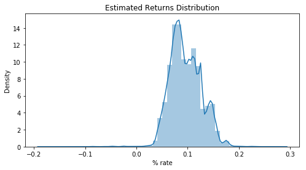

```python
# plot the distribution of estimated return
plt.figure(figsize=[8,4])
sb.distplot(df_clean['EstimatedReturn'])
plt.title('Estimated Returns Distribution')
plt.xlabel('% rate')
plt.ylabel('Density');
```

From the above table and the plot, it can be seen that most of the estimated return fall between 7.5% to 11.5%. Besides, it should be noted that the distribution of estimated returns is a multimodal distribution, which implies that there are many popular estimated return rates. One interesting finding is that there are also negative estimated returns (from -18% to below 0%). The reason may be these loans have estimated yield lower than the estimated principal loss on charge-offs.

> 1. Loan original amount

```python
# looking at the loan original amount
df_clean['LoanOriginalAmount'].describe()
```

```
count    84853.000000
mean      9083.440515
std       6287.860058
min       1000.000000
25%       4000.000000
50%       7500.000000
75%      13500.000000
max      35000.000000
Name: LoanOriginalAmount, dtype: float64
```

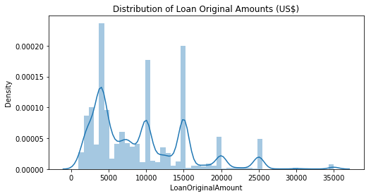

```python
plt.figure(figsize=[8,4])
sb.distplot(df_clean['LoanOriginalAmount'])
plt.title('Distribution of Loan Original Amounts (US$)')
plt.ylabel('Density');
```

This distribution is multimodal, with many frequent loan amounts. Taking into consideration that median of loan original amount is 7500USD, less than the mean which is 9083USD, the distribution of loan amount is skewed to the right. It can be confirmed in the histogram, when we see there are very few loans with the amount from 20000USD to 35000USD, and the most of the loans are from 0 to 15000.

> 1. Loan Terms

```python
# looking at the distribution of loan term
df_clean['Term'].value_counts(normalize=True)*100
```

```
36    69.172569
60    28.926496
12     1.900935
Name: Term, dtype: float64
```

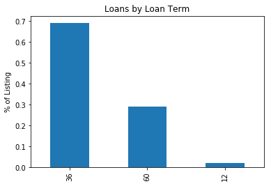

```python
# plot the number of loans based on loan term
plt.figsize=[12,8]
df_clean['Term'].value_counts(normalize=True).plot(kind='bar')
plt.title('Loans by Loan Term')
plt.ylabel('% of Listing');
```

The plot demonstrates that the most popular loan term is 36 months, which account for nearly 70% of the loans, whilst 12-month loans are the least popular with only 2% of total number of loans.

**Now, we will see the description of features of borrowers.**

> 1. Borrower APR

In the following, we will find out the most popular borrower APR (the APR with highest count).

```python
# the most popular borrower APR
df_clean.BorrowerAPR.value_counts(normalize=True)
```

```
0.35797    0.043275
0.35643    0.019375
0.30532    0.010630
0.29510    0.008803
0.35356    0.008497
0.15833    0.007672
0.24246    0.007130
0.24758    0.007083
0.12528    0.006588
0.15324    0.006446
0.17359    0.006446
0.27462    0.006293
0.27285    0.005963
0.13799    0.005763
0.12691    0.005374
0.25781    0.005233
0.26528    0.005068
0.19501    0.005009
0.20462    0.004950
0.23318    0.004903
0.34621    0.004785
0.11296    0.004761
0.29537    0.004608
0.20200    0.004596
0.32446    0.004455
0.14714    0.004372
0.37453    0.004325
0.15223    0.004278
0.19859    0.004266
0.17522    0.004266
             ...
0.11454    0.000012
0.30398    0.000012
0.36983    0.000012
0.17358    0.000012
0.26272    0.000012
0.16910    0.000012
0.35860    0.000012
0.21233    0.000012
0.35874    0.000012
0.27174    0.000012
0.20443    0.000012
0.27002    0.000012
0.31258    0.000012
0.35909    0.000012
0.16552    0.000012
0.25613    0.000012
0.30917    0.000012
0.16917    0.000012
0.35842    0.000012
0.28646    0.000012
0.06738    0.000012
0.23794    0.000012
0.18278    0.000012
0.12198    0.000012
0.31438    0.000012
0.18094    0.000012
0.11853    0.000012
0.21760    0.000012
0.16914    0.000012
0.18875    0.000012
Name: BorrowerAPR, Length: 2330, dtype: float64
```

```python
df_clean['BorrowerAPR'].describe()
```

```
count    84853.000000
mean         0.226658
std          0.079916
min          0.045830
25%          0.163280
50%          0.219450
75%          0.292540
max          0.423950
Name: BorrowerAPR, dtype: float64
```

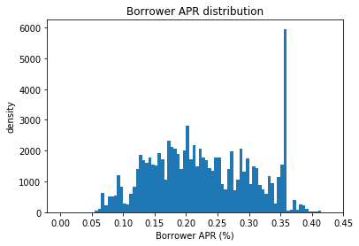

```python
# plot BorrowerAPR values
bins = np.arange(0, df_clean['BorrowerAPR'].max(), 0.005)
plt.hist(data = df_clean, x = 'BorrowerAPR', bins = bins)
plt.title('Borrower APR distribution')
plt.xlabel('Borrower APR (%)')
plt.ylabel('density')
plt.xticks(np.arange(0, df_clean['BorrowerAPR'].max()+0.05, 0.05));
```

> 1. Prosper Score

```python
# calculate the proportion of each Prosper Score
df_clean['ProsperScore'].value_counts(normalize=True)
```

```
4.0     0.148433
6.0     0.144697
8.0     0.142046
7.0     0.124887
5.0     0.115647
3.0     0.090062
9.0     0.081447
2.0     0.067953
10.0    0.055979
11.0    0.017159
1.0     0.011691
Name: ProsperScore, dtype: float64
```

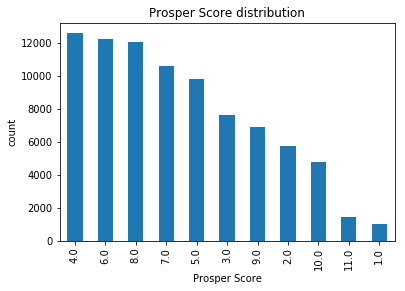

```python
# see which ProsperScore borrowers received the most

plt.figsize=(38,18)
df_clean['ProsperScore'].value_counts().plot(kind='bar')
plt.title('Prosper Score distribution')
plt.xlabel('Prosper Score')
plt.ylabel('count')
plt.fontsize = 12;
```

From both the table and the plot, it is apparent that the prosper scores from 4 to 8 dominate the data. The low score (from 1 to 3) and the high score (from 9 to 11) are less likely to be observed.

> 1. Prosper Ratings

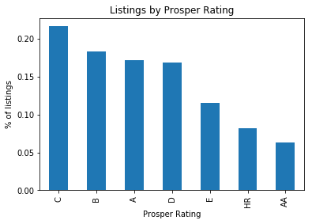

```python
# plot the distribution of all prosper ratings
figsize=[8,4]
df_clean['ProsperRating (Alpha)'].value_counts(normalize=True).plot(kind='bar', sort_columns=True)
plt.title('Listings by Prosper Rating')
plt.xlabel('Prosper Rating')
plt.ylabel('% of listings');
```

Prosper rating A, B, C are the most common rating in the loans made, while rating D, E, HR are less likely to be. It is noticable that Prosper Rating AA is the least popular rating.

> 1. Borrower APR of each Prosper Rating

```python
# the borrower APR for each prosper rating
ProsperRating_mean = df_clean.groupby('ProsperRating (Alpha)').BorrowerAPR.mean().sort_values()
ProsperRating_mean
```

```
ProsperRating (Alpha)
AA    0.090041
A     0.138909
B     0.184030
C     0.226124
D     0.280581
E     0.330551
HR    0.356061
Name: BorrowerAPR, dtype: float64
```

The above table represents a predictable relationship between the borrower APR and the prosper rating. There is a negative relationship between them. For the prosper rating which are better, the APR will be lower, and vice versa, with worse rating, the borrower has to pay higher interest rate.

> 1. Occupations and Employment status of borrowers

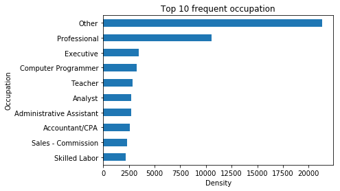

```python
# see the top 10 occupations of borrowers

df_clean['Occupation'].value_counts()[9::-1].plot(kind='barh')
plt.title('Top 10 frequent occupation')
plt.xlabel('Density')
plt.ylabel('Occupation')
plt.fontsize = 12
plt.figsize=(18,12);
```

Not taking Other into account (possibly because the borrowers do not want to disclose their job at the time they created the listing), the most popular occupations are professionals such as executive, computer programmer, teacher, analyst, accountant, or other types of skilled labor.

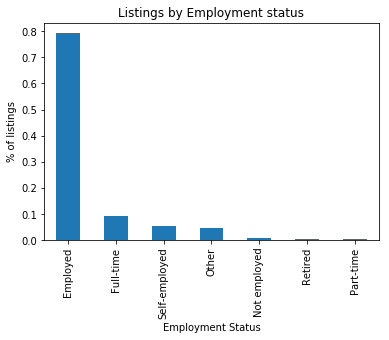

```python
# the distribution of loans for various employment status
figsize=[8,4]
df_clean['EmploymentStatus'].value_counts(normalize=True).plot(kind='bar', sort_columns=True)
plt.title('Listings by Employment status')
plt.ylabel('% of listings')
plt.xlabel('Employment Status');
```

```python
# calculate the percentage of loans allocated to different employment status
df_clean['EmploymentStatus'].value_counts(normalize=True)
```

```
Employed         0.793254
Full-time        0.093420
Self-employed    0.053481
Other            0.044854
Not employed     0.007649
Retired          0.004325
Part-time        0.003017
Name: EmploymentStatus, dtype: float64
```

From the above plot and table, employed people are more likely to receive a loan, as 80% of the originations are allocated to the employed, while not employed, part time and retired people are less likely to get an origination.

> 1. Income Range of borrowers

```python
# the distribution of income range
df_clean['IncomeRange'].value_counts(normalize=True)*100
```

```
$50,000-74,999    30.201643
$25,000-49,999    28.490448
$100,000+         17.919225
$75,000-99,999    17.086019
$1-24,999          5.484780
Not employed       0.764852
$0                 0.053033
Name: IncomeRange, dtype: float64
```

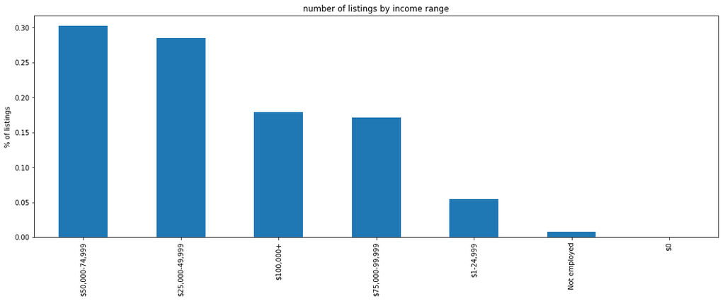

```python
# plot the number of listings by income range
df_clean['IncomeRange'].value_counts(normalize=True).plot(kind='bar',figsize=[18,6])

plt.title('number of listings by income range')
plt.ylabel('% of listings');
```

There are very few loans given to borrowers with no income or no occupation. The total number of loans given to these 2 groups is less than 1% of total number of loans. The group with income less than 25000 USD accounts for 5.5% of the listings. The group with income more than 75000 USD accounts for 35% of the loans. The most frequent borrowers have the income from 25000 - 75000 USD, with 59% of total listings.

> 1. Home ownership of borrowers (owning a house or having a mortgage)

```python
# calculate the percentage of borrowers are home owner
df_clean['IsBorrowerHomeowner'].value_counts(normalize=True)
```

```
True     0.528538
False    0.471462
Name: IsBorrowerHomeowner, dtype: float64
```

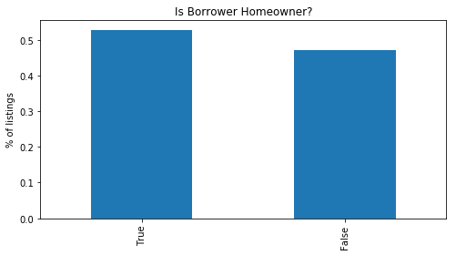

```python
# plot the percentage of borrowers are home owner
df_clean['IsBorrowerHomeowner'].value_counts(normalize=True).plot(kind='bar', figsize=[8,4], title='Is Borrower Homeowner?').set_ylabel('% of listings');
```

It seems that the borrowers tend to have a mortgage on their credit profile or provide documentation confirming they are a homeowner rather than not having a house/mortgage.

> 1. Reasons to loan

```python
# the most popular category of the listing
df_clean['ListingCategoryAlpha'].value_counts(normalize=True)*100
```

```
Debt Consolidation    62.673093
Other                 10.863493
Home Improvement       8.015038
Business               6.243739
Auto                   2.636324
Household Expenses     2.352303
Medical/Dental         1.793690
Taxes                  1.042980
Large Purchases        1.032374
Wedding Loans          0.908630
Vacation               0.905095
Motorcycle             0.358267
Student Use            0.322911
Engagement Ring        0.255736
Baby&Adoption          0.234523
Cosmetic Procedure     0.107244
Boat                   0.100173
Green Loans            0.069532
RV                     0.061282
Not Available          0.023570
Name: ListingCategoryAlpha, dtype: float64
```

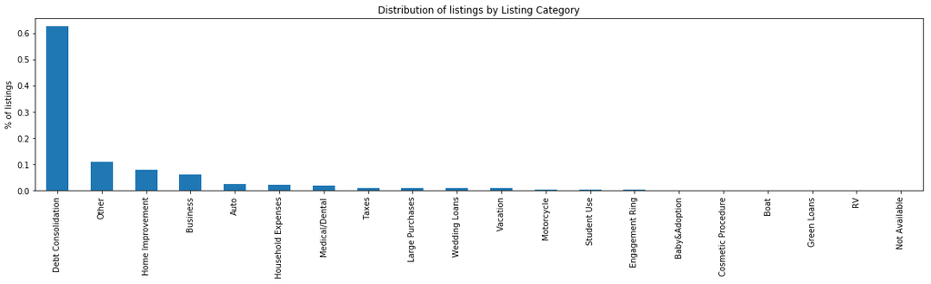

```python
# plot originations based on the category of listing
df_clean['ListingCategoryAlpha'].value_counts(normalize=True).plot(kind='bar', figsize=[20,4], title='Distribution of listings by Listing Category').set_ylabel('% of listings');
```

The most frequent reason to have a loan is for debt consolidation (62.70%).

> 1. Number of inquiries that the borrowers have attempted in the last six months.

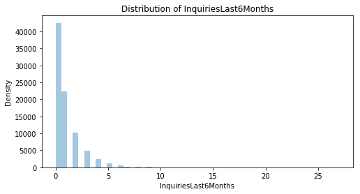

```python
plt.figure(figsize=[8,4])
sb.distplot(df_clean['InquiriesLast6Months'], kde = False)
plt.title('Distribution of InquiriesLast6Months')
plt.ylabel('Density');
```

**Summary about univariate exploration**

> Original loan amount distribution is multimodal, with many frequent loan amounts. Taking into consideration that median of loan original amount is 7500USD, less than the mean which is 9083USD, the distribution of loan amount is skewed to the right. It can be confirmed in the histogram, when we see there are very few loans with the amount from 20000USD to 35000USD, and the most of the loans are from 0 to 15000.

> There is one noticable variable, which is the borrower APR. Since there are two APR which have much higher counts (at a outstanding level) than the rest of the APR, the distribution is skewed to the right.

> The distribution of estimated returns is a multimodal distribution, which implies that there are many popular estimated return rates. One interesting finding is that there are also negative estimated returns (from -18% to below 0%). However, there are reasons for this. May be these loans have estimated yield lower than the estimated principal loss on charge-offs. Thus, I did not perform any transformation or operations on this unusual distribution.

## Bivariate Exploration

*This part aims to find out if there is any bivariate relationship between the group of two variables.*

> **Does house ownership affect Prosper rating of borrowers?**

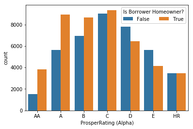

```python
# plot the prosper rating by owning house/relating mortgage
ax = sb.countplot(data = df_clean, x = 'ProsperRating (Alpha)', hue = 'IsBorrowerHomeowner', order = ['AA', 'A', 'B', 'C', 'D', 'E', 'HR'])
ax.legend(ncol = 3, framealpha = 1, title = 'Is Borrower Homeowner?');
```

The above plot confirms that the prosper rating is related to the homeowner status of the borrowers. With better rating, the borrowers are more likely to have homeowner status (own a house or have mortgage). For the first 4 rating AA to C, the borrowers are homeowner. For the lower quality rating of D, E, the borrowers are less likely to be a homeowner. It is understandable since a borrower with a house or a mortgage tends to be rated better and receive better rating. However, the most interesting thing is that the lowest rating, HR, observes the same proportion of homeowner and not homeowner. Thus, it leads to another insight that there are many other factors affecting the rating of a borrower besides the homeowner status.

> **Is Borrower APR affected by Prosper Score, Prosper Rating and Credit score?**

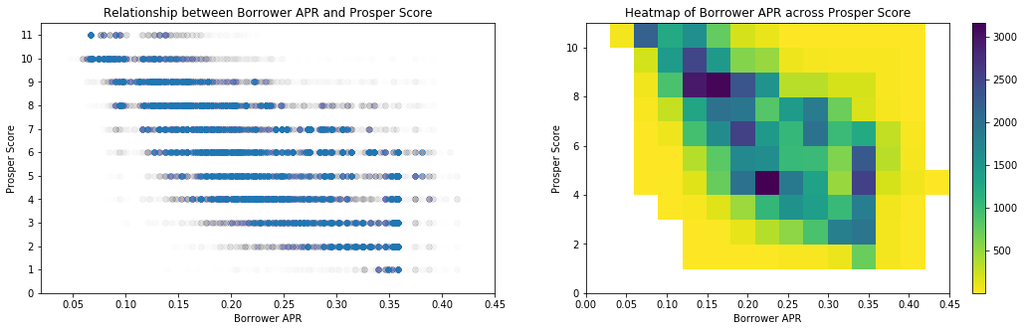

```python
# scatter plot and heatmap for the relationship between Prosper Score and Borrower APR.
plt.figure(figsize = [18, 5])

plt.subplot(1, 2, 1)
plt.scatter(data = df_clean, x = 'BorrowerAPR', y = 'ProsperScore', alpha =  0.005)
plt.yticks(np.arange(0, 12, 1))
plt.title('Relationship between Borrower APR and Prosper Score')
plt.xlabel('Borrower APR')
plt.ylabel('Prosper Score')


plt.subplot(1, 2, 2)
bins_x = np.arange(0, df_clean['BorrowerAPR'].max()+0.05, 0.03)
bins_y = np.arange(0, df_clean['ProsperScore'].max()+1, 1)
plt.hist2d(data = df_clean, x = 'BorrowerAPR', y = 'ProsperScore', bins = [bins_x, bins_y],
               cmap = 'viridis_r', cmin = 0.5)
plt.colorbar()
plt.title('Heatmap of Borrower APR across Prosper Score')
plt.xlabel('Borrower APR')
plt.ylabel('Prosper Score');
```

The heat map shows clearly the relationship between prosper score and borrower APR: They have a negative relationship. When prosper score increases, the borrower APR decreases. It makes sense since loans with higher prosper score are more reliable, gain more trust and credit from the lenders and thus have lower BorrowerAPR. Vice versa, with lower prosper score, the borrowers are less likely to be reliable and trusted by the lenders and have to pay higher APR. Now we will use heatmap to see the relationship between borrower rate with credit score.

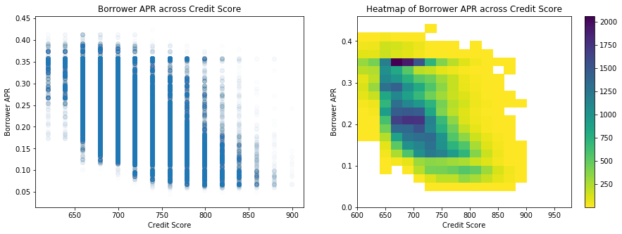

```python
# scatter plot and heatmap for relationship between credit score and Borrower APR.
plt.figure(figsize = [15, 5])

plt.subplot(1, 2, 1)
plt.scatter(data = df_clean, x = 'CreditScoreRangeUpper', y = 'BorrowerAPR', alpha = 0.01)
plt.title('Borrower APR across Credit Score')
plt.xlabel('Credit Score')
plt.ylabel('Borrower APR');


plt.subplot(1, 2, 2)
bins_x = np.arange(600, df_clean['CreditScoreRangeUpper'].max()+100, 20)
bins_y = np.arange(0, df_clean['BorrowerAPR'].max()+0.05, 0.02)
plt.hist2d(data = df_clean, x = 'CreditScoreRangeUpper', y = 'BorrowerAPR', bins = [bins_x, bins_y],
               cmap = 'viridis_r', cmin = 0.5)
plt.colorbar()
plt.title('Heatmap of Borrower APR across Credit Score')
plt.xlabel('Credit Score')
plt.ylabel('Borrower APR');
```

The heatmap confirms the previous finding about the relationship between borrower APR and score. The relationship between credit score and borrower APR is negative.

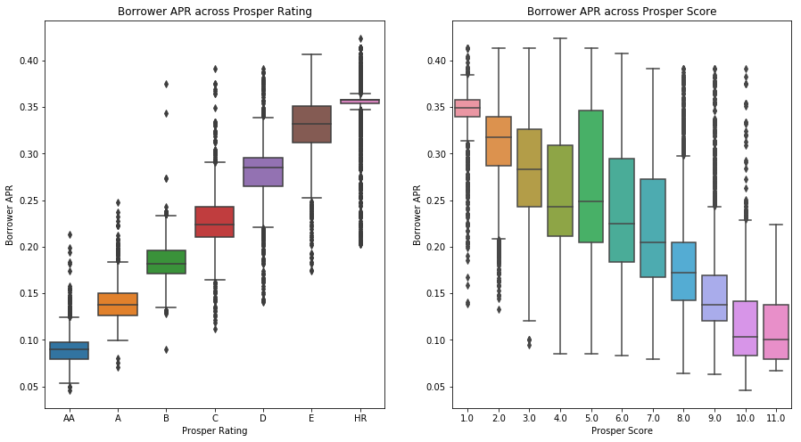

```python
# box plot for Borrower APR and Prosper Rating & Prosper Score
# shows lower Borrower APR for better ratings/score

plt.figure(figsize = [20, 5])

plt.subplot(1, 2, 1)
sb.boxplot(data = df_clean, x = 'ProsperRating (Alpha)', y = 'BorrowerAPR', order = ['AA', 'A', 'B', 'C', 'D', 'E', 'HR'])
plt.gcf().set_size_inches(15, 8)
plt.title('Borrower APR across Prosper Rating')
plt.xlabel('Prosper Rating')
plt.ylabel('Borrower APR')

plt.subplot(1, 2, 2)
sb.boxplot(data = df_clean, x = 'ProsperScore', y = 'BorrowerAPR')
plt.gcf().set_size_inches(15, 8)
plt.title('Borrower APR across Prosper Score')
plt.xlabel('Prosper Score')
plt.ylabel('Borrower APR');
```

The above box plots still confirm the prediction and the insight found previously: the better the rating/score of the loans, the lower the APR.

The left box plot demonstrates the relationship between prosper rating and borrower APR. The relationship between prosper rating and the APR is negative. When the prosper rating goes down from AA to HR (from good rating to bad rating), the borrower APR increases. It means that the lenders facilitate the loans with good rating by low APR. On the other hand, for the loans with bad quality (low rating), it can be seen that the APR is very high.

The right plot shows a negative relationship between Prosper Score and borrower APR. The higher the score (the better the quality of borrowers), the lower the APR.

> **Is estimated return affected by Prosper score or Prosper rating?**

```python
#Median of estimated return across Prosper Rating categories

df_clean.groupby('ProsperRating (Alpha)')['EstimatedReturn'].median().sort_values(ascending=True)
```

```
ProsperRating (Alpha)
AA    0.05100
A     0.06663
B     0.08215
C     0.09220
D     0.11630
HR    0.12210
E     0.12390
Name: EstimatedReturn, dtype: float64
```

```python
#Median of estimated return across Prosper score

df_clean.groupby('ProsperScore')['EstimatedReturn'].median().sort_values(ascending=True)
```

```
ProsperScore
11.0    0.053420
10.0    0.057820
9.0     0.070100
8.0     0.078240
7.0     0.089220
4.0     0.096090
6.0     0.100100
3.0     0.104065
5.0     0.108700
2.0     0.110700
1.0     0.124600
Name: EstimatedReturn, dtype: float64
```

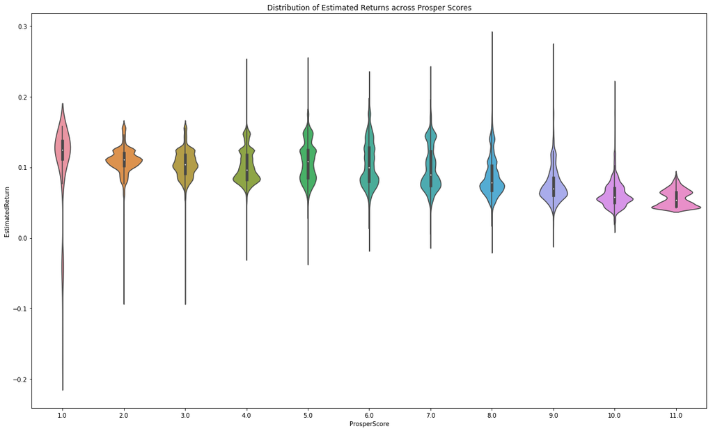

```python
# violin plot of estimated return for each prosper score

plt.figure(figsize=[20,12])
sb.violinplot(data=df_clean, x='ProsperScore', y='EstimatedReturn')
plt.title('Distribution of Estimated Returns across Prosper Scores');
```

The above violin plot illustrates three main insights:

- Firstly, similar to the negative relationship between credit score and borrower APR, the relationship between credit score and estimated return is negative. For the loans with better prosper score, the lenders receive lower estimated return. The loans with better prosper score are more reliable and credit worthy, thus the lenders have lower levels of risk, and low risk is associated with low return. On the other hand, the loans with lower score are riskier, and the lenders receive higher return to trade off for the risks they have to bear.
- Secondly, this plot and the above plot confirm the relationship between estimated return and borrower APR. With lower APR, the lenders receive lower return.
- Besides those insights, the violin plot reveals another insight: the fluctuation of estimated return for each prosper score. Although lower prosper score loans can bring back to lenders higher estimated return, they also have the most tremendous variability and instability. For instance, for the loan with prosper score of 1, the estimated return varies from -20% to 20%, a very large volatility. This volatility is smaller when the prosper score goes up. For the loans with score of 11, the fluctuation is very small and the range of estimated return is very small and always positive. It infers that the lenders have to bear very low risk of not getting return.

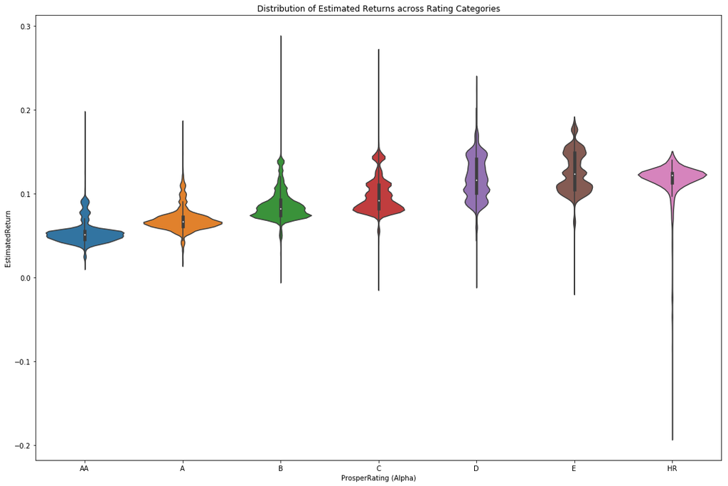

```python
# violin plot of estimated return for each Prosper rating

plt.figure(figsize=[18,12])
sb.violinplot(data=df_clean, x='ProsperRating (Alpha)', y='EstimatedReturn', order=['AA','A','B','C','D','E','HR']).set_title('Distribution of Estimated Returns across Rating Categories')
```

This violin plot reveals the relationship between return and credit rating of the loans. The loans with better rating provide the lenders with lower estimated return than the loans with worse credit ratings. However, it is associated with higher risks. Looking at the plot, it can be seen that the fluctuation of estimated return for good credit rating is smaller than for worse rating. For the loans with credit rating AA, the lenders have to bear very low risk of not getting return as the return is always positive. The plot of this rating is only on the positive side. On the other hand, the rating HR has a very high risk of getting a negative return. Although its median is above 10%, the lenders may have a loss of up to 20%.

> **How does loan term affect estimated return and loan amount?**

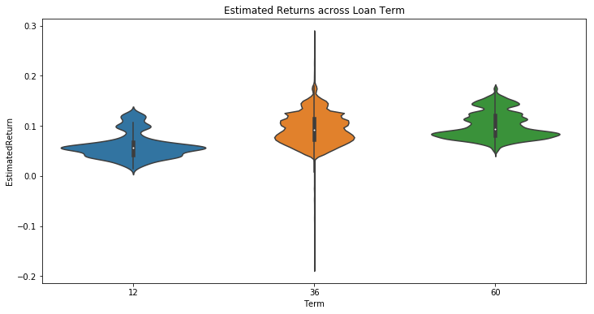

```python
plt.figure(figsize=[12,6])
sb.violinplot(data=df_clean, x='Term', y='EstimatedReturn').set_title('Estimated Returns across Loan Term');
```

It is demonstrated that the estimated returns are higher for the loans of longer term. Besides, we can see that the returns for 3-year loans are the most volatile in the three types of loan terms.

```python
#Median amounts across loan terms
df_clean.groupby('Term')['LoanOriginalAmount'].median().sort_values(ascending=True)
```

```
Term
12     3500
36     5500
60    11500
Name: LoanOriginalAmount, dtype: int64
```

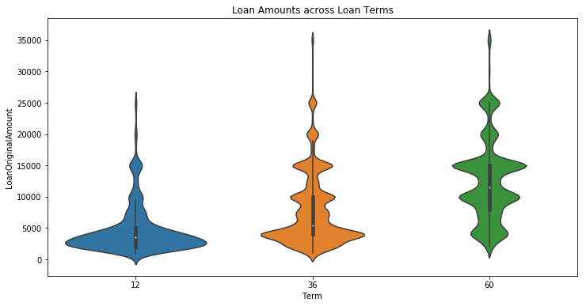

```python
plt.figure(figsize=[12,6])
sb.violinplot(x='Term', y='LoanOriginalAmount', data=df_clean).set_title('Loan Amounts across Loan Terms');
```

It is demonstrated that the loan original amount is higher for the loans of longer term. Whilst the 1-year loan ranges from 0 to 25000 USD, the amount for 3-year and 5-year loan goes up to 35000 USD. The median amount of 1 year loan is 3500 USD, for 3 year loan is 5500 USD and that for 5 year is 11500 USD.

Besides, the plot also demonstrates that while for 1-year loan, the loan amount of less than 5000 USD is most frequent, the most frequent amount of 3year loan is 5000 USD and for 5 year is 10000 and 15000 USD.

> **Are borrower rate and loan amount affected by borrowers' income?**

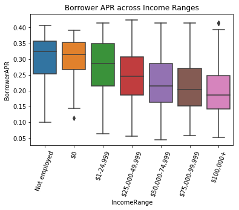

```python
# box plot of borrower APR across income ranges
# to see if the borrower APR is affected by the income of the borrowers

g = sb.boxplot(data = df_clean, x = 'IncomeRange', y = 'BorrowerAPR', order=['Not employed', '$0', '$1-24,999', '$25,000-49,999','$50,000-74,999',  '$75,000-99,999','$100,000+'])
g.set_xticklabels(g.get_xticklabels(), rotation=70)
plt.title('Borrower APR across Income Ranges');
```

The box plot indicates that the borrower APR tends to be lower for the borrowers with higher income. It can be explained that the borrowers with higher income tend to have higher financial stability and the ability to pay back the loan, hence they receive higher trust and credit rating from the lenders. Hence, they can get the loans at lower APR.

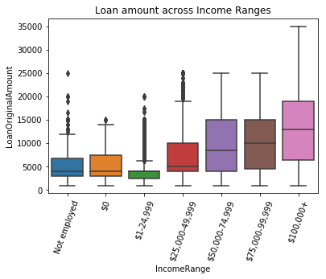

```python
# box plot of loan amount granted across income ranges
# to see if the loan amount is affected by the income of the borrowers

g = sb.boxplot(data = df_clean, x = 'IncomeRange', y = 'LoanOriginalAmount', order=['Not employed',  '$0', '$1-24,999', '$25,000-49,999','$50,000-74,999',  '$75,000-99,999','$100,000+'])
g.set_xticklabels(g.get_xticklabels(), rotation=70)
plt.title('Loan amount across Income Ranges');
```

The box plot demonstrates that the loan amount tends to be higher for the borrowers with higher income. It can be explained that the borrowers with higher income tend to have higher financial stability and the ability to pay back the loan, hence they receive higher trust and credit rating from the lenders. Hence, they can get the larger amount of loan. Therefore, the granted amount of loan will be higher if the borrower has higher income.

> **How does loan reason category affect borrower APR, estimated return and loan amount?**

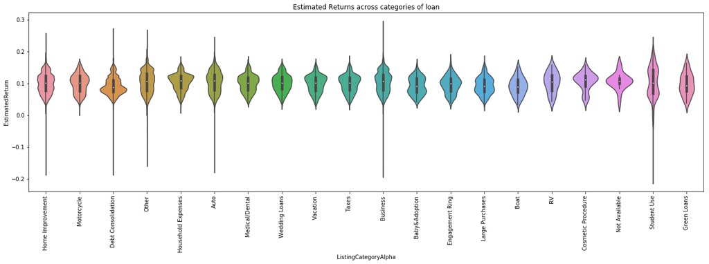

```python
# violin plot to see the estimated returns across different loan reason category

plt.figure(figsize=[22,6])
g = sb.violinplot(data=df_clean, x='ListingCategoryAlpha', y='EstimatedReturn')
plt.title('Estimated Returns across categories of loan')
g.set_xticklabels(g.get_xticklabels(), rotation=90);
```

The median of estimated returns for various listing categories are not very different. The return rates are most volatile for the loans of home improvement, debt consolidation, auto and business. This is understandable since loans for business purposes are risky and cannot guarantee the profitability. However, the most surprising finding is that loans for student use are also very risky. This is unpredictable.

```python
df_clean.groupby('ListingCategoryAlpha')['BorrowerAPR'].mean().sort_values()
```

```
ListingCategoryAlpha
Boat                  0.205051
Baby&Adoption         0.215822
Debt Consolidation    0.218002
Large Purchases       0.221856
Engagement Ring       0.228982
Motorcycle            0.229840
Green Loans           0.230642
Home Improvement      0.230709
Student Use           0.237241
Wedding Loans         0.238488
RV                    0.238492
Taxes                 0.239886
Business              0.240598
Vacation              0.241323
Medical/Dental        0.242020
Auto                  0.245561
Other                 0.247937
Household Expenses    0.258617
Cosmetic Procedure    0.262957
Not Available         0.272537
Name: BorrowerAPR, dtype: float64
```

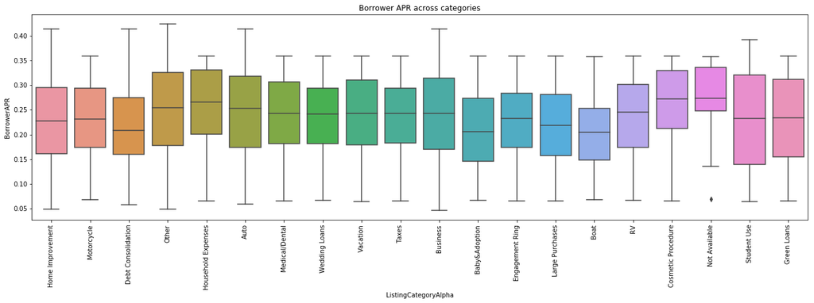

```python
# violin plot to see the borrower APR across different listing reason category

plt.figure(figsize=[22,6])
g = sb.boxplot(data=df_clean, x='ListingCategoryAlpha', y='BorrowerAPR')
plt.title('Borrower APR across categories')
g.set_xticklabels(g.get_xticklabels(), rotation=90);
```

The plot shows that the borrower APR is lower for the loans which are used for debt consolidation, baby adoption or large purchase. On the other hand, if the borrowers want to gain the fund for household expenses or cosmetic procedure, they will have to pay for higher borrower APR.

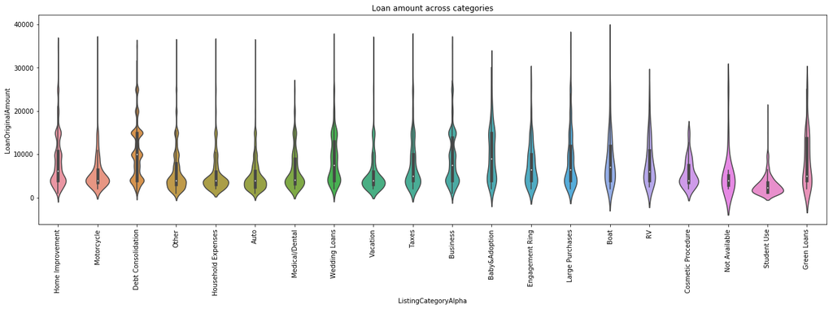

```python
# violin plot to see the loan amount across different listing reason category

plt.figure(figsize=[22,6])
g = sb.violinplot(data=df_clean, x='ListingCategoryAlpha', y='LoanOriginalAmount')
plt.title('Loan amount across categories')
g.set_xticklabels(g.get_xticklabels(), rotation=90);
```

It seems that listing category is not associated with loan amount.

### Some of the relationships observed

> 1. On borrowers side:
- Borrower APR tends to be lower for the borrowers with higher income. It can be explained that the borrowers with higher income tend to have higher financial stability and the ability to pay back the loan, hence they receive higher trust and credit rating from the lenders. Hence, they can get the loans at lower APR.
- Loan amount tends to be higher for the borrowers with higher income. It can be explained that the borrowers with higher income tend to have higher financial stability and the ability to pay back the loan, hence they receive higher trust and credit rating from the lenders. Hence, they can get the larger amount of loan.
- Prosper rating is related to the homeowner status of the borrowers. With better rating, the borrowers are more likely to have homeowner status (own a house or have mortgage) (e.g. for the first 4 rating AA to C). For the lower quality rating of D, E, the borrowers are less likely to be a homeowner. It is understandable since a borrower with a house or a mortgage tends to be rated better and receive better rating. However, the most interesting thing is that the lowest rating, HR, observes the same proportion of homeowner and not homeowner. Thus, it leads to another insight that there are many other factors affecting the rating of a borrower besides the homeowner status.
- The heat map shows clearly the relationship between prosper score and borrower APR: They have a negative relationship. When prosper score increases, the borrower APR decreases. It makes sense since loans with higher prosper score are more reliable, gain more trust and credit from the lenders and thus have lower BorrowerAPR. Vice versa, with lower prosper score, the borrowers are less likely to be reliable and trusted by the lenders and have to pay higher APR.
- Also, the better the rating/score of the loans, the lower the APR.
> 1. On lenders side:
- Firstly, the relationship between credit score and estimated return is negative. For the loans with better prosper score, the lenders receive lower estimated return. The loans with better prosper score are more reliable and credit worthy, thus the lenders have lower levels of risk, and low risk is associated with low return. On the other hand, the loans with lower score are riskier, and the lenders receive higher return to trade off for the risks they have to bear.
- Secondly, with better quality loan and lower borrowers APR, the lenders receive lower return.
- However, although lower prosper score loans can bring back to lenders higher estimated return, they also have the most tremendous variability and instability. For instance, for the loan with prosper score of 1, the estimated return varies from -20% to 20%, a very large volatility. This volatility is smaller when the prosper score goes up. For the loans with score of 11, the fluctuation is very small and the range of estimated return is very small and always positive. It infers that the lenders have to bear very low risk of not getting return for good score/rating loans.
- The loans with better rating provide the lenders with lower estimated return than the loans with worse credit ratings. However, it is associated with higher risks. For the loans with credit rating AA, the lenders have to bear very low risk of not getting return as the return is always positive. The plot of this rating is only on the positive side. On the other hand, the rating HR has a very high risk of getting a negative return. Although its median is above 10%, the lenders may have a loss of up to 20%.
- Loan original amount is higher for the loans of longer term. Whilst the 1-year loan ranges from 0 to 25000 USD, the amount for 3-year and 5-year loan goes up to 35000 USD. The median amount of 1 year loan is 3500 USD, for 3 year loan is 5500 USD and that for 5 year is 11500 USD.

## Multivariate Exploration

> Plots of three or more variables to investigate the data

**1. Borrower APR related features**

> **Borrower APR and Prosper Score, Prosper Rating and Credit score**

In the bivariate exploration, we have found out that borrower APR is affected by Prosper score, rating and credit score. We will dive deeper in this part with multivariate plot.

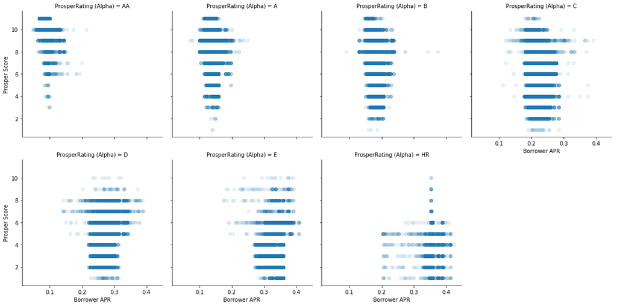

```python
# facet grid to see relationship between borrower APR, Prosper Score and rating
prosper_borrower = sb.FacetGrid(data = df_clean, col = 'ProsperRating (Alpha)', col_order= ['AA', 'A', 'B', 'C', 'D', 'E', 'HR'], col_wrap = 4, height = 4)
prosper_borrower.map(plt.scatter, 'BorrowerAPR', 'ProsperScore', alpha = 0.1)
prosper_borrower.set_xlabels('Borrower APR')
prosper_borrower.set_ylabels('Prosper Score')

plt.show();
```

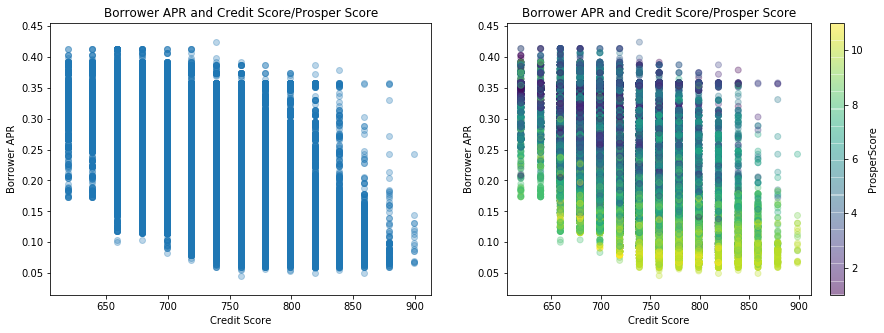

```python
# plot relationship between credit score, Prosper Score and borrower APR

plt.figure(figsize = [15, 5])

plt.subplot(1, 2, 1)
plt.scatter(data = df_clean, x = 'CreditScoreRangeUpper', y = 'BorrowerAPR', alpha = 0.3)
plt.title('Borrower APR and Credit Score/Prosper Score')
plt.ylabel('Borrower APR')
plt.xlabel('Credit Score');


plt.subplot(1, 2, 2)
plt.scatter(data = df_clean, x = 'CreditScoreRangeUpper', y = 'BorrowerAPR', c ='ProsperScore', alpha = 0.3)
plt.colorbar(label = 'ProsperScore')
plt.title('Borrower APR and Credit Score/Prosper Score')
plt.xlabel('Credit Score')
plt.ylabel('Borrower APR');
```

It can be seen clearly that for borrowers with higher credit score, the borrower APR is lower. Similarly, for borrowers with better Prosper Score, the APR is lower. It confirms the point that credit score and prosper score are negatively correlated to Borrower APR.

*In summary, the above plots confirm what are demonstrated in the previous part.*

> **In the previous part, it is apparent that the borrower APR is negatively correlated with income of the borrowers and the Prosper score. We will plot borrower APR across various income ranges and prosper score to see if the relationship is confirmed. In addition, ownership of a house will be added into the plot as a condition.**

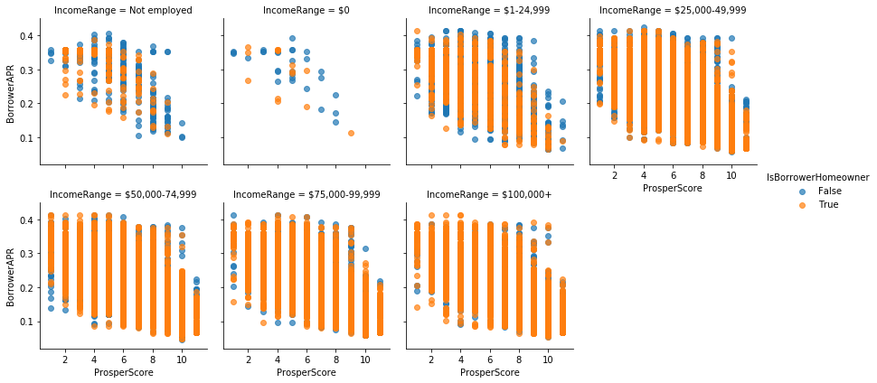

```python
# facet grid to plot relationship between borrower APR, Prosper Score, Income range and ownership of house

g = sb.FacetGrid(df_clean, col = "IncomeRange", col_wrap = 4, col_order=['Not employed',  '$0', '$1-24,999', '$25,000-49,999','$50,000-74,999',  '$75,000-99,999','$100,000+'], hue="IsBorrowerHomeowner")
g.map(plt.scatter, "ProsperScore", "BorrowerAPR", alpha=.7)
g.add_legend();
```

The prosper score goes in line with the income of the borrowers. For the borrowers with higher income, the prosper score is higher and the borrower APR is lower. Moreover, there are more borrowers with higher income who own a house or has a related mortgage.

> **How is borrower APR different across estimated return and Prosper score?**

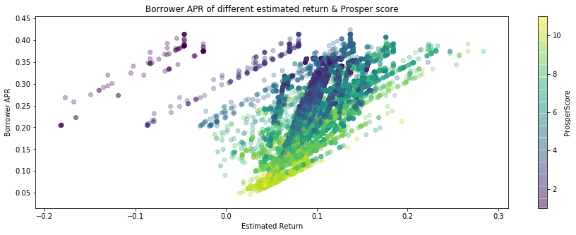

```python
# plot relationship between borrower APR across various estimated return and Prosper score

plt.figure(figsize = [15, 5])
plt.scatter(data = df_clean, x = 'EstimatedReturn', y = 'BorrowerAPR', c ='ProsperScore', alpha = 0.3)
plt.colorbar(label = 'ProsperScore')
plt.title('Borrower APR of different estimated return & Prosper score')
plt.xlabel('Estimated Return')
plt.ylabel('Borrower APR');
```

From the plot, it is clear that the borrower APR is very high for negative estimated return. This is explained by the prosper score. We can see that all the negative estimated returns are associated with low prosper score. It means that those loans are at bad ratings, risky and unreliable. Thus, the APR is high to help the lenders trade off the risk. Also, because those loans are risky, they tend to bring negative return to the lenders.

On the other hand, for the positive estimated return, high score loans are correlated with low borrower APR. Especially for prosper score from 9-11, the estimated return is low but always positive, ensuring low return and low risk. With lower prosper score, the return is estimated to be higher, as well as borrower APR.

**2. Loan amount related features**

> **How is loan amount correlated with Prosper score and income?**

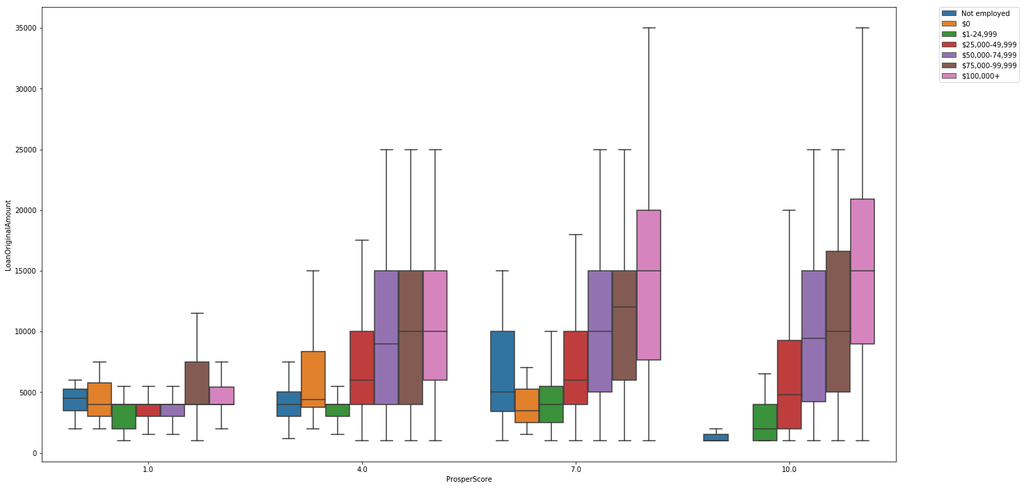

```python
# plot relationship between Loan amount, Prosper Score and income range

df_trim = df_clean.query('ProsperScore == [1,4,7,10]')

plt.figure(figsize=[22,12])

ax = sb.boxplot(x="ProsperScore", y="LoanOriginalAmount", hue="IncomeRange", hue_order=['Not employed',  '$0', '$1-24,999', '$25,000-49,999','$50,000-74,999',  '$75,000-99,999','$100,000+'], data=df_trim, fliersize=0)

plt.legend(bbox_to_anchor=(1.05, 1), loc=2, borderaxespad=0.);
```

For the borrowers with higher income and higher prosper score, the amount of loan tends to be higher. The borrowers with lower income tend to have lower Prosper score and lower amount of loan.

> **What Prosper rating and Loan terms help borrowers gain the highest loan amount?**

```python
#Table of % of loan amounts across Rating Categories and Loan Terms
df_clean.groupby(['ProsperRating (Alpha)', 'Term'])['LoanOriginalAmount'].sum().sort_values(ascending=False)/df_clean['LoanOriginalAmount'].sum()*100
```

```
ProsperRating (Alpha)  Term
A                      36      14.626424
C                      60      12.908709
B                      60      11.873934
C                      36      11.645936
B                      36      11.420019
D                      36       7.884918
A                      60       6.830624
AA                     36       6.530912
D                      60       5.071879
E                      36       4.399014
HR                     36       3.115987
AA                     60       1.419369
E                      60       1.289398
B                      12       0.200854
C                      12       0.179493
A                      12       0.177886
D                      12       0.161343
E                      12       0.140121
AA                     12       0.123179
Name: LoanOriginalAmount, dtype: float64
```

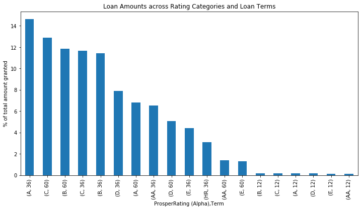

```python
# plot loan amount across various terms and ratings

(df_clean.groupby(['ProsperRating (Alpha)', 'Term'])['LoanOriginalAmount'].sum().sort_values(ascending=False)/df_clean['LoanOriginalAmount'].sum()*100).plot(kind='bar',figsize=(12,6))
plt.title('Loan Amounts across Rating Categories and Loan Terms')
plt.ylabel('% of total amount granted');
```

Most of the amount of loans is granted to borrowers with good credit rating (A, B, C) rather than bad credit rating (D, E, HR). The amount of loans granted to rating AA is low, since the proportion of this rating in the borrower lists is also very low. In addition, the loan amount tends to be larger for longer term (36-month and 60-month) rather than shorter term (12 month).

> **How is loan amount affected by loan term and Prosper score, with being homeowner as a condition?**

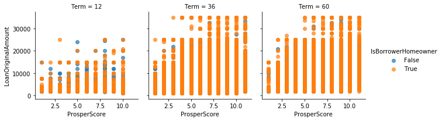

```python
# plot relationship between loan amount across various terms and scores, with the condition of being homeowner

g = sb.FacetGrid(df_clean, col = "Term", hue="IsBorrowerHomeowner")
g.map(plt.scatter, "ProsperScore", "LoanOriginalAmount", alpha=.7)
g.add_legend();
```

Amount of loan is smaller for shorter term and becomes larger for longer term. Moreover, for longer term, the borrowers are more likely to be a home owner than in shorter term.

**3. Number of inquiries related features**